# reproducible-res-project2.Rmd

# **Title:**

### Analysis of severe weather effects on US public health and economy

## **Synopsis:**

###### Storms and other severe weather events can cause both public health and economic problems for communities and municipalities. Many severe events can result in fatalities, injuries, and property damage, and preventing such outcomes to the extent possible is a key concern.

###### This project involves exploring the U.S. National Oceanic and Atmospheric Administration’s (NOAA) storm database. This database tracks characteristics of major storms and weather events in the United States, including when and where they occur, as well as estimates of any fatalities, injuries, and property damage.

###### This analysis will summarize effects of extereme wether conditions.

## **Data Processing**

Download bz2 file and load table into memory

```r
readData <- function()
{
  dir.create("temp",showWarnings = FALSE)
  dataURL <- "https://d396qusza40orc.cloudfront.net/repdata%2Fdata%2FStormData.csv.bz2"
  if(!file.exists("./temp/weather.bz2"))
  {
    download.file(dataURL,"./temp/weather.bz2")
  }

  # check if reducedStormData variable already exists
  dataSet <- NULL
  if(file.exists("./temp/weathercache.RData"))
  {
    #load("./temp/weathercache.RData")
    #print(paste("Dataset loaded from cache. Rows:  ", nrow(dataSet)))
    #don't return dataset if it cache exists
  }
  else
  {
    dataSet <- read.csv("weather.bz2")
    print(paste("Dataset loaded from start. Rows:  ", nrow(dataSet)))
  }
  dataSet
}
dataSet <- readData()
```

### Transformation

Dataset takes too long to process. Recude the size and keep only recent, more accurate years of observations.

Columns to keep

- **EVTYPE** for event analysis
- **FATALITIES** and **INJURIES** for health damage
- **-DMG-** columns for economic damage

Alphabetical characters used to signify magnitude include

- **K** for thousands
- **M** for millions
- **B** for billions

If additional precision is available, it may be provided in the narrative part of the entry

```r
reduceSize <- function()
{
  if(file.exists("./temp/weathercache.RData"))
  {
    load("./temp/weathercache.RData")
    print(paste("slimSet loaded from cache. Rows:  ", nrow(slimSet)))
    return(slimSet)
  }
  dataSet$Date = as.Date(dataSet$BGN_DATE, format = "%m/%d/%Y")
  tempDS <- subset(dataSet,
                   Date > as.Date("01/01/2000",format = "%m/%d/%Y") &
                     EVTYPE != "?" &
                     (INJURIES > 0 | FATALITIES > 0 | PROPDMG > 0 | PROPDMG > 0)
  )

  keepCols <- c("EVTYPE", "FATALITIES", "INJURIES",
                "PROPDMG", "PROPDMGEXP", "CROPDMG", "CROPDMGEXP","Date")

  slimSet <- tempDS[,keepCols]


  slimSet$PropertyDamage <- mapply(fixAmount, as.numeric(slimSet$PROPDMG), slimSet$PROPDMGEXP)
  slimSet$CropDamage <- mapply(fixAmount, as.numeric(slimSet$CROPDMG), slimSet$CROPDMGEXP)
  save(slimSet, file="./temp/weathercache.RData")
  slimSet
}

fixAmount <- function(tempAmt, powerInd)
{
  amount <- NULL
  if (powerInd == "" | powerInd == " ")
  {
    amount <- tempAmt
  }
  else if (powerInd == "K")
  {
    amount <- tempAmt * 10^3
  }
  else if (powerInd == "M")
  {
    amount <- tempAmt * 10^6
  }
  else if (powerInd == "B")
  {
    amount <- tempAmt * 10^9
  }
  else
  {
    print(paste(c("Unexpected power: ",powerInd)))
  }
  amount
}

slimSet <- reduceSize()
```

```
## [1] "slimSet loaded from cache. Rows:   152513"
```

## Results

Get top 20 weather events that threaten public health by fatalities and injuries

```
##                     EVTYPE FATALITIES INJURIES
## 1                  TORNADO       1193    15213
## 2           EXCESSIVE HEAT       1013     3708
## 3              FLASH FLOOD        600      812
## 4                LIGHTNING        466     2993
## 5              RIP CURRENT        340      208
## 6                    FLOOD        266      315
## 7                     HEAT        231     1222
## 8                AVALANCHE        179      126
## 9                HIGH WIND        131      677
## 10       THUNDERSTORM WIND        130     1400
## 11 EXTREME COLD/WIND CHILL        125       24
## 12            RIP CURRENTS        122      175
## 13               TSTM WIND        116     1753
## 14            WINTER STORM        104      434
## 15             STRONG WIND         97      263
## 16         COLD/WIND CHILL         95       12
## 17               HIGH SURF         78      133
## 18                WILDFIRE         75      911
## 19       HURRICANE/TYPHOON         64     1275
## 20          TROPICAL STORM         50      267
```

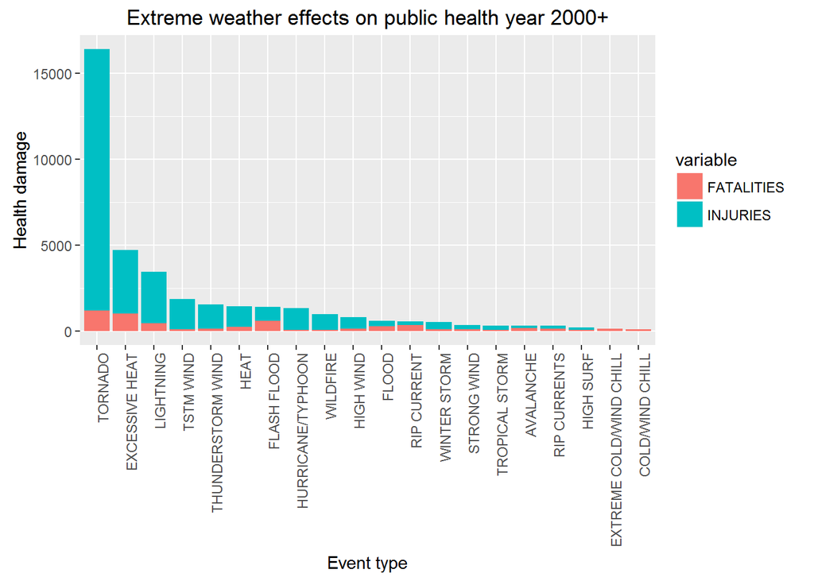

```r
analyzeHealth <- function()
{
  eventFatalities <- aggregate(FATALITIES ~ EVTYPE, slimSet, sum)
  eventInjuries <- aggregate(INJURIES ~ EVTYPE, slimSet, sum)
  merged <- arrange(merge(eventFatalities, eventInjuries, by.x = "EVTYPE"), desc(FATALITIES))
  print(merged[1:20,])
  melted <- melt(merged[1:20,], c("EVTYPE"))


  g <- ggplot(melted, aes(x = reorder(factor(EVTYPE),-value), value)) +
    geom_bar(stat="identity", aes(fill = variable)) +
    xlab("Event type") +
    ylab("Health damage") +
    ggtitle('Extreme weather effects on public health year 2000+') +
    theme(axis.text.x = element_text(angle = 90, hjust = 1))
  print(g)
}
analyzeHealth()
```

Get top 20 weather events that damage property and crops

```
##               EVTYPE PropertyDamage CropDamage
## 1              FLOOD   134691074080 3053909400
## 2  HURRICANE/TYPHOON    69305840000 2607822800
## 3        STORM SURGE    43170935000          0
## 4            TORNADO    19460679560  225965400
## 5               HAIL    11988535920 1192613100
## 6        FLASH FLOOD    11876755110  886291500
## 7     TROPICAL STORM     7194930550  391175000
## 8          HIGH WIND     4945515420  497477000
## 9           WILDFIRE     4758667000  193293900
## 10  STORM SURGE/TIDE     4641188000     850000
## 11 THUNDERSTORM WIND     3382654440  319598000
## 12         HURRICANE     3043806010  448980000
## 13         ICE STORM     2920205820    8665000
## 14  WILD/FOREST FIRE     2355295000    3370000
## 15         TSTM WIND     2148130280  217550800
## 16      WINTER STORM     1389510200     153000
## 17           DROUGHT      846646000  285175000
## 18         LIGHTNING      598002370     793000
## 19        HEAVY RAIN      463252040   14152000
## 20        HEAVY SNOW      326123730     330000
```

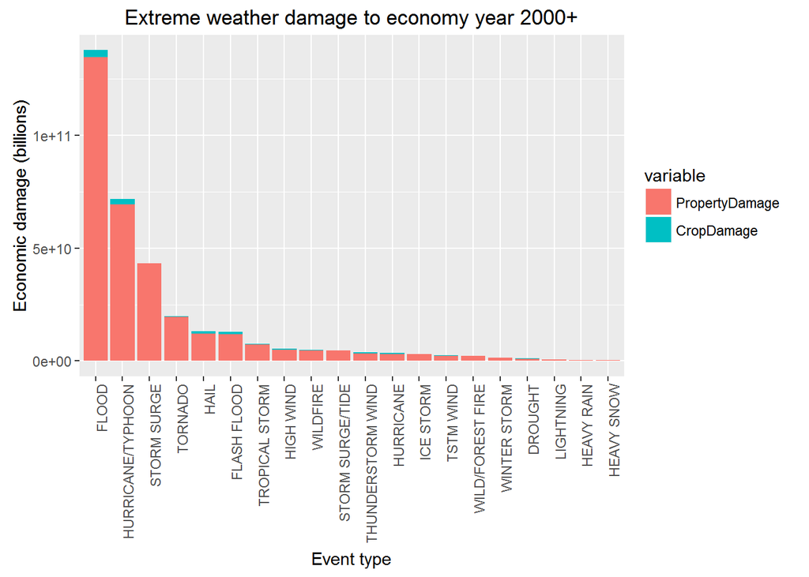

```r
analyzeEconomy <- function()
{
  propDamage <- aggregate(PropertyDamage ~ EVTYPE, slimSet, sum)
  cropDamage <- aggregate(CropDamage ~ EVTYPE, slimSet, sum)
  mergedEco <- arrange(merge(propDamage, cropDamage, by.x = "EVTYPE"), desc(PropertyDamage))
  print(mergedEco[1:20,])
  meltedEco <- melt(mergedEco[1:20,], c("EVTYPE"))

  g <- ggplot(meltedEco, aes(x = reorder(factor(EVTYPE),-value), value)) +
    geom_bar(stat="identity", aes(fill = variable)) +
    #geom_text(aes(label = round(value/10^9,1), y = value), size = 3) +
    xlab("Event type") +
    ylab("Economic damage (billions)") +
    ggtitle('Extreme weather damage to economy year 2000+') +
    theme(axis.text.x = element_text(angle = 90, hjust = 1))
  print(g)
}
analyzeEconomy()
```

## Conclusions

#### Public health analysis:

###### Tornadoes and excessive heat are the most damaging weather events with respect

###### to the fatalities and injuries among population.

#### Economy damage analysis:

###### Floods are by far the most devastating events to property and crops, followed by hurricanes and storm surges. The crop damage pales in comparrisson to personal and public property from any top weather event.